# Network Analysis with R

The Networking Archives project is using tools from other disciplines to write histories of seventeenth-century intelligencing and correspondence. Key in the toolset for the project is network analysis. Network analysis is a suite of tools developed to understand and analyse networks, specifically, network graphs, a formal term for a mathematical graph of entities, known as nodes, connected by vertices, or edges. Mostly they boil down to either specific software packages with a GUI, such as [Gephi](https://gephi.org/) or [Palladio](https://hdlab.stanford.edu/palladio/), or dedicated libraries within a coding language such as Python’s [NetworkX](https://networkx.org/) or R’s [Igraph](https://igraph.org/r/).

Using existing software is a great way to get started, but doing network analysis with a programming language is much more flexible, and, I would argue, a better investment of time because you’ll inevitably learn transferable coding skills along the way. There are tonnes of free tools available for converting data into a network format. This blog post is an outline of my network analysis workflow using R. It’s meant for anyone who either uses or intends to use the [programming language R](https://www.rstudio.com/) and the suite of tools called the [tidyverse](https://www.tidyverse.org/) for data science and would like to know what is (in my opinion) the easiest and most portable method for analysing networks. It’s not a full tutorial: there are lots out there already (Jesse Sadler’s [tutorial](https://www.jessesadler.com/post/network-analysis-with-r/) is excellent)

One of the easiest data formats to construct a network is an edge list: a simple dataframe with two columns, representing the connections between two nodes, one per row. It makes particular sense with correspondence data, which is often stored as a table of letters with a ‘from’ and a ‘to’—more or less a ready-made edge list. In a correspondence dataset you might also have multiple sets of each of the edges (multiple letters between the same pair of individuals). You can add this to the edge list as an attribute called weight, which is simply another column.

I use three R network libraries to do almost everything network-related, from analysis to visualisation: `igraph`, `tidygraph` and `ggraph`. My goal is to port everything to a format which is really easy to work with using existing my data analysis workflow. That format is known as ‘tidy data’, and it is a way of working with data which is easily transferable across a range of uses. It also means you need to learn very little new programming to do network analysis if you stay within this ‘ecosystem’.

### Import Network Data with the Tidyverse

The whole workflow uses four packages. The first is `tidyverse`, a collection of various packages used for data wrangling and analytics.

```r
library(dplyr)
library(magrittr)
library(readr)
library(stringr)
```

Next I need some network data. On the project this is generally a comma separated values file containing the information for one letter per row. We turn the raw letter data into an edge list in a standardised format, with the from/to information, a letter date, a place, and a unique identifier for the letter. Because the dataset is large and the same names are often used repeatedly, we use a unique ID number rather than people or place names when constructing the edge list. The nice thing about working within the tidyverse is that it’s easy to then match the IDs back to actual names afterwards.

These edge lists can be turned into a network object using `tidygraph` and the function `as_tbl_graph`. This function takes the first two columns in a dataset and turns them into the network graph, using any additional columns as attributes. We use two separate tables of data. First, an edge list, using unique, unambiguous numeric IDs for people and place names. Next, additional lookup tables, just with the unique ID, the person’s name, and additional information, if you have it (which can be used to filter the network afterwards).

```r
letters = read_csv("https://raw.githubusercontent.com/yann-ryan/dh_intro_gates/main/sample_letter_data_network.csv", col_types = cols(.default = "c"))
```

If you have multiple letters between individuals, you can sum them and use as a weight in the network, or you can ignore it. You can do this with `tidyverse` commands: `group_by()` and `tally()`, changing the name of the new column to ‘weight’.

```r
edge_list = letters %>%
  group_by(author, recipient) %>%
  tally(name = 'weight')
```

### Turn the edge list into a tbl_graph

Next transform the edge list into a network object called a tbl_graph, using [tidygraph](https://www.data-imaginist.com/2017/introducing-tidygraph/). A tbl_graph is a graph object which can be manipulated using tidyverse grammar. This means you can create a network and then use a range of standard data analysis functions on it as needed, without learning a whole new set of commands.

First, load the tidygraph library. Use `as_tbl_graph()` to turn the edge list into a network. The first two columns will be taken as the from and to data, and any additional columns added as attributes. It’ll automatically create a nodes table, too.

```r
library(tidygraph)

sample_tbl_graph = edge_list %>%
  as_tbl_graph()

sample_tbl_graph
```

```
## # A tbl_graph: 417 nodes and 479 edges
## #
## # A directed acyclic simple graph with 1 component
## #
## # Node Data: 417 x 1 (active)
##   name
##   <chr>
## 1 Agnes Austin
## 2 Alice Thurrgood
## 3 Amye Champernowne
## 4 Ane Carnsew
## 5 Arthur Remys
## 6 Arthur Strode
## # … with 411 more rows
## #
## # Edge Data: 479 x 3
##    from    to weight
##   <int> <int>  <int>
## 1     1   124      1
## 2     2   117      1
## 3     3   100      1
## # … with 476 more rows
```

The tbl_graph is an object with two tables, one for the edges and one for the nodes. You can access each of the tables using the function activate(nodes) or activate(edges). The active table has (active) after it.

```r
sample_tbl_graph = sample_tbl_graph %>%
  activate(edges)

sample_tbl_graph
```

```
## # A tbl_graph: 417 nodes and 479 edges
## #
## # A directed acyclic simple graph with 1 component
## #
## # Edge Data: 479 x 3 (active)
##    from    to weight
##   <int> <int>  <int>
## 1     1   124      1
## 2     2   117      1
## 3     3   100      1
## 4     4    81      1
## 5     5   125      1
## 6     5   113      1
## # … with 473 more rows
## #
## # Node Data: 417 x 1
##   name
##   <chr>
## 1 Agnes Austin
## 2 Alice Thurrgood
## 3 Amye Champernowne
## # … with 414 more rows
```

Tidygraph allows you to perform calculations on the tbl_graph using `mutate`, using standard igraph algorithms. So for example to calculate the degree of every node:

```r
sample_tbl_graph %>%
  activate(nodes) %>%
  mutate(degree = centrality_degree(mode = 'total'))
```

```
## # A tbl_graph: 417 nodes and 479 edges
## #
## # A directed acyclic simple graph with 1 component
## #
## # Node Data: 417 x 2 (active)
##   name              degree
##   <chr>              <dbl>
## 1 Agnes Austin           2
## 2 Alice Thurrgood        1
## 3 Amye Champernowne      1
## 4 Ane Carnsew            1
## 5 Arthur Remys           3
## 6 Arthur Strode          2
## # … with 411 more rows
## #
## # Edge Data: 479 x 3
##    from    to weight
##   <int> <int>  <int>
## 1     1   124      1
## 2     2   117      1
## 3     3   100      1
## # … with 476 more rows
```

If you run standard functions meant to be used on a dataframe, they will happen to the active table. So if you wanted to filter just edges from ID 1, for example, you could use the `filter` verb from dplyr:

```r
sample_tbl_graph %>% filter(from ==1)
```

```
## # A tbl_graph: 417 nodes and 1 edges
## #
## # A rooted forest with 416 trees
## #
## # Edge Data: 1 x 3 (active)
##    from    to weight
##   <int> <int>  <int>
## 1     1   124      1
## #
## # Node Data: 417 x 1
##   name
##   <chr>
## 1 Agnes Austin
## 2 Alice Thurrgood
## 3 Amye Champernowne
## # … with 414 more rows
```

```r
sample_tbl_graph %>%
  activate(nodes)%>%
  filter(str_detect(name, "(?i)sir"))
```

```
## # A tbl_graph: 14 nodes and 4 edges
## #
## # A rooted forest with 10 trees
## #
## # Node Data: 14 x 1 (active)
##   name
##   <chr>
## 1 Sir Faithful Fortescue
## 2 Sir Phelim O&#x0027;Neill
## 3 Sir Richard
## 4 Sir Richard Carnsew
## 5 Sir Lucas Dillon
## 6 Sir Luke Fitzgerald
## # … with 8 more rows
## #
## # Edge Data: 4 x 3
##    from    to weight
##   <int> <int>  <int>
## 1     1    10      1
## 2     1    11      1
## 3     3     9      1
## # … with 1 more row
```

Slightly more useful might be to filter based on some calculation you’ve made previously. The data format allows you to use dplyr pipes (%>%) to perform one calculation on the data, then pass that new dataframe along to the next function. It works really well with tidygraph. Here we calculate the degree scores first, then filter to include only nodes with a degree score over two:

```r
sample_tbl_graph %>%
  activate(nodes) %>%
  mutate(degree = centrality_degree(mode = 'total')) %>%
  filter(degree >2)
```

```
## # A tbl_graph: 48 nodes and 76 edges
## #
## # A directed acyclic simple graph with 5 components
## #
## # Node Data: 48 x 2 (active)
##   name                                                              degree
##   <chr>                                                              <dbl>
## 1 Arthur Remys                                                           3
## 2 Capt. Nicholas Burton                                                  3
## 3 Captain Brandon Cusacke                                                4
## 4 Christopher Creed                                                      3
## 5 Commissioners of the Supreme Council of the Confederate Catholics     10
## 6 Committee for Public Revenue                                           3
## # … with 42 more rows
## #
## # Edge Data: 76 x 3
##    from    to weight
##   <int> <int>  <int>
## 1     1    36      1
## 2     1    37      1
## 3     2    33      1
## # … with 73 more rows
```

### Visualisation with ggraph

The last step in the workflow is visualising the network. You can use igraph and standard R plotting libraries for this, but I use a package called ggraph, which uses the same language as ggplot (a very well-known visualisation library for R) and adds some special functions to visualise networks. To create a network diagram, first use the function `ggraph` on your tbl_graph, then add the special [ggraph geoms](https://ggplot2.tidyverse.org/reference/) `geom_node_point()` and `geom_edge_link()`

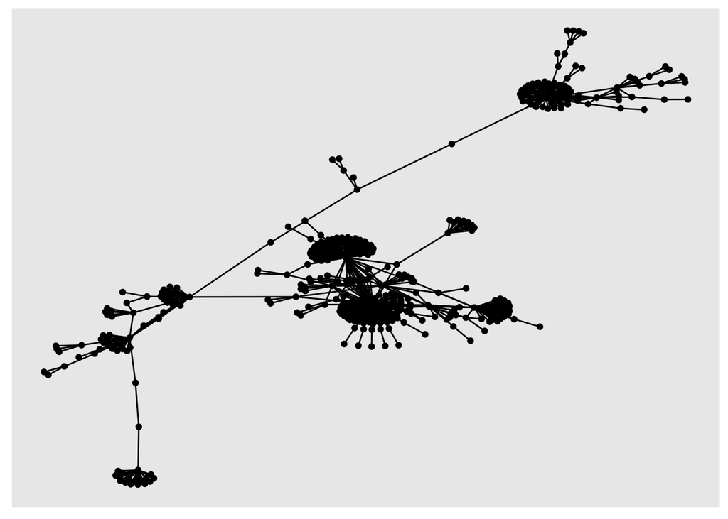

```r
library(ggraph)
sample_tbl_graph %>% ggraph('nicely') + geom_node_point() + geom_edge_link()
```

You can use the dplyr pipes to perform calculations, filter the data and then visualise it, all in one go:

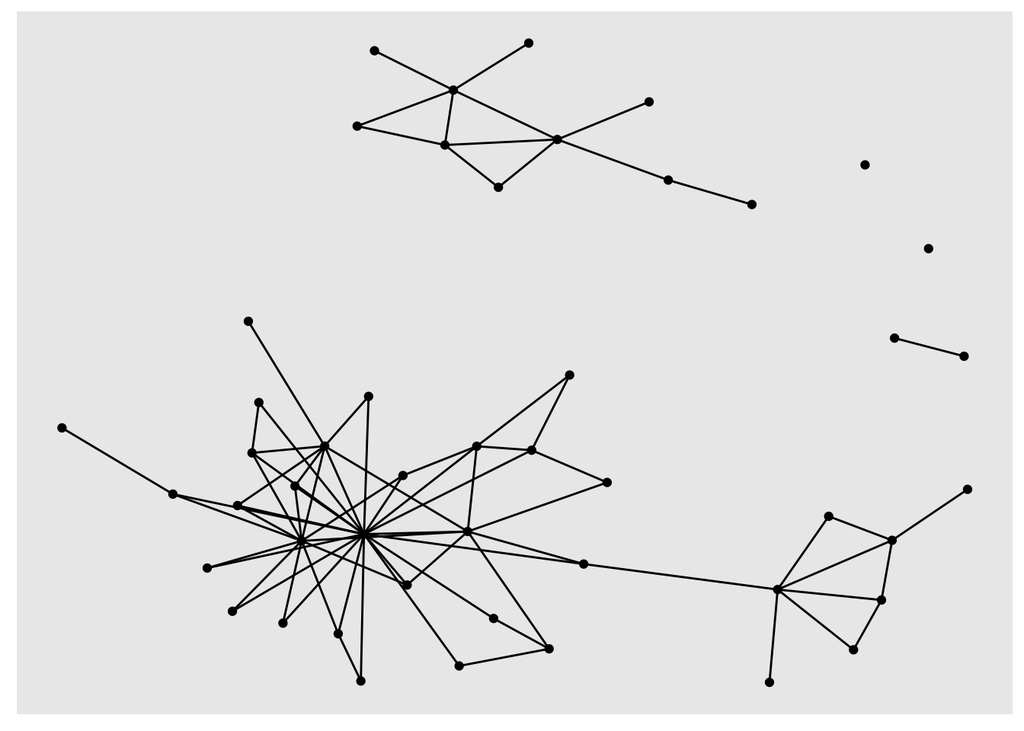

```r
sample_tbl_graph %>%
  activate(nodes)%>%
  mutate(degree = centrality_degree(mode = 'total')) %>%
  filter(degree >2) %>%
  ggraph('nicely') +
  geom_node_point() +
  geom_edge_link()
```

`geom_node_point()` and `geom_edge_link` take aesthetics, just like regular ggplot geoms. You can calculate degree scores and then set the size of the nodes to the result:

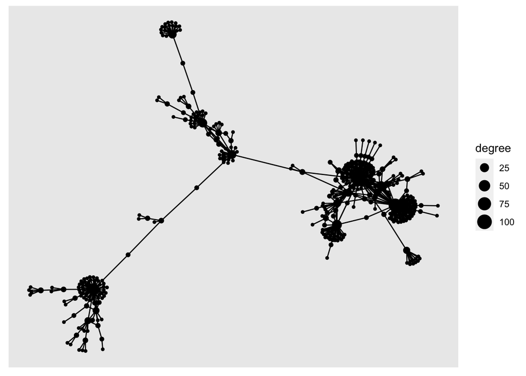

```r
sample_tbl_graph %>%
  activate(nodes)%>%
  mutate(degree = centrality_degree(mode = 'total'))  %>%
  ggraph('nicely') +
  geom_node_point(aes(size = degree)) +
  geom_edge_link()
```

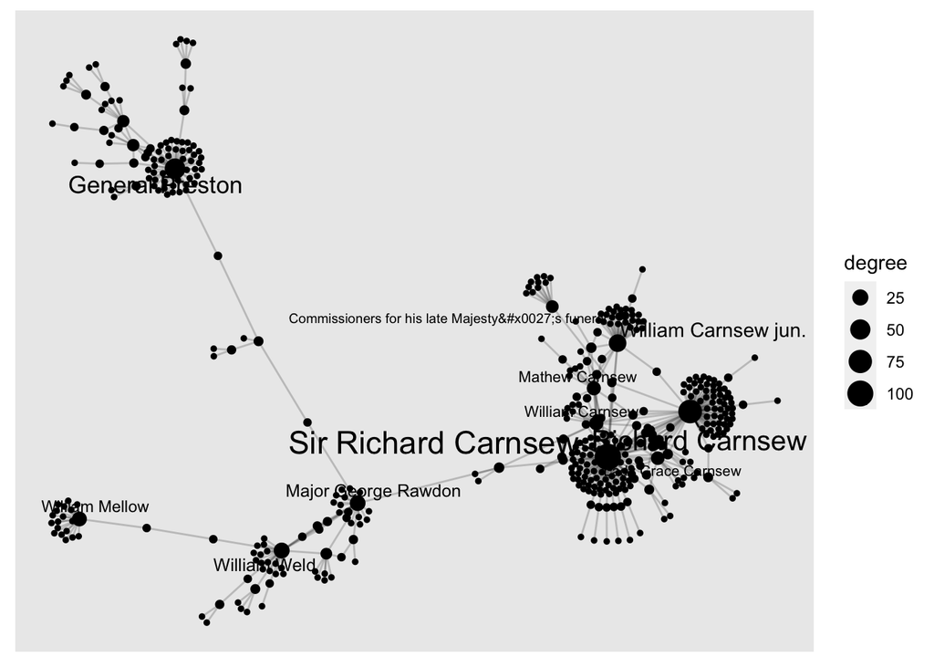

```r
sample_tbl_graph %>%
  activate(nodes)%>%
  mutate(degree = centrality_degree(mode = 'total'))  %>%
  ggraph('nicely') +
  geom_node_point(aes(size = degree)) +
  geom_node_text(aes(label = if_else(degree >10, name, NULL), size = degree), repel = TRUE) +
  geom_edge_link(alpha = .2)
```